# Master en Big Data. Fundamentos Matemáticos del Análisis de Datos (FMAD).

Tarea 2

Ana Blasi Sanchiz

Curso 2021-22. Última actualización: 2021-09-24

# Instrucciones preliminares

- Empieza abriendo el proyecto de RStudio correspondiente a tu repositorio personal de la asignatura.
- En todas las tareas tendrás que repetir un proceso como el descrito en la sección *Repite los pasos Creando un fichero Rmarkdown para esta práctica* de la *Práctica00*. Puedes releer la sección *Practicando la entrega de las Tareas* de esa misma práctica para recordar el procedimiento de entrega.

# Ejercicio 1. Simulando variables aleatorias discretas.

**Apartado 1:** La variable aleatoria discreta $X1$ tiene esta tabla de densidad de probabilidad (es la variable que se usa como ejemplo en la Sesión ):
$$\begin{array}{|c|c|c|c|c|c|c|}
\hline
\text{valor de }X1 & 0 & 1 & 2 & 3 \\
\hline
\text{Probabilidad de ese valor }P(X = x_i) & \dfrac{64}{125} &
\dfrac{48}{125}& \dfrac{12}{125} & \dfrac{1}{125}\rule{0mm}{6mm} \\[3mm]
\hline
\end{array}$$
Calcula la media y la varianza teóricas de esta variable.

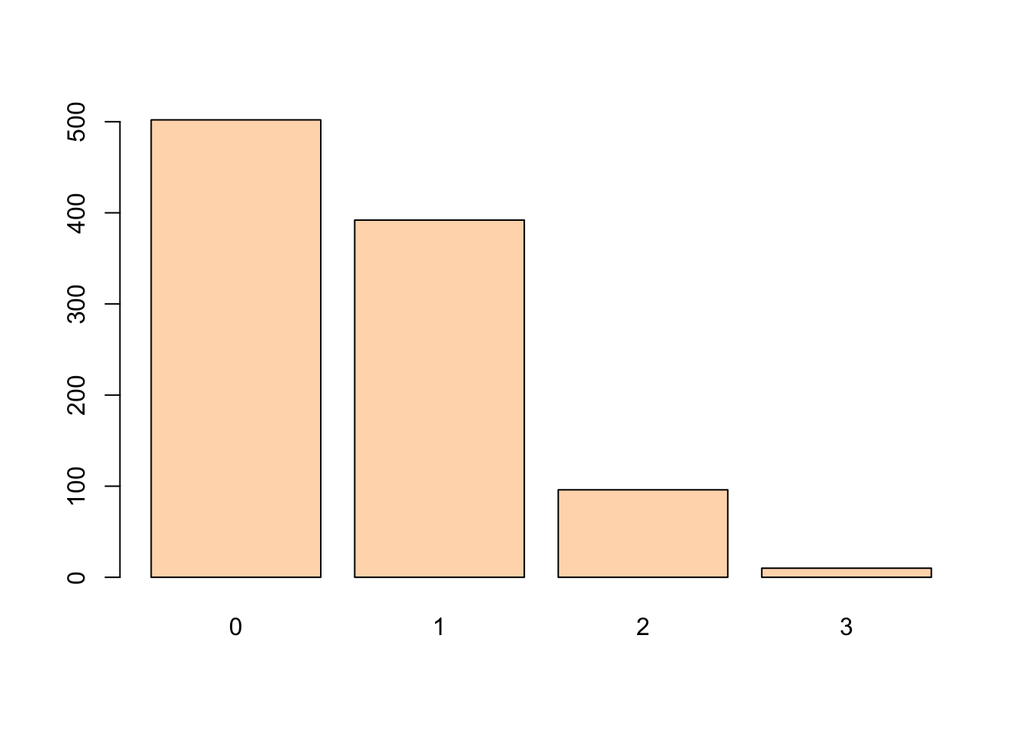

```r
x1 <- sample(0:3,size=1000, replace=TRUE,prob=c(64/125,48/125,12/125,1/125))
barplot(table(x1),col="peachpuff")
```

Media de x1

```r
x=c(0,1,2,3)
probX1=c(64/125,48/125,12/125,1/125)
(mediaX1 = sum(x*probX1))
```

```
## [1] 0.6
```

```r
(varianzaX1 = (sum(x*probX1))-(mediaX1^2))
```

```
## [1] 0.24
```

**Apartado 2:** Combina `sample` con `replicate` para simular cien mil muestras de tamaño 10 de esta variable $X1$. Estudia la distribución de las medias muestrales como hemos hecho en ejemplos previos, ilustrando con gráficas la distribución de esas medias muestrales. Cambia después el tamaño de la muestra a 30 y repite el análisis.

```r
k=100000
mediasMuestrales10 <- replicate(k,{
  Z=sample(x1,size=10,replace=TRUE)
  mean(Z)
  })
head(mediasMuestrales10, 10)
```

```
##  [1] 0.7 0.5 0.5 0.7 0.7 0.5 0.3 0.8 0.2 0.2
```

Representación gráfica de la distribución de las medias muestrales

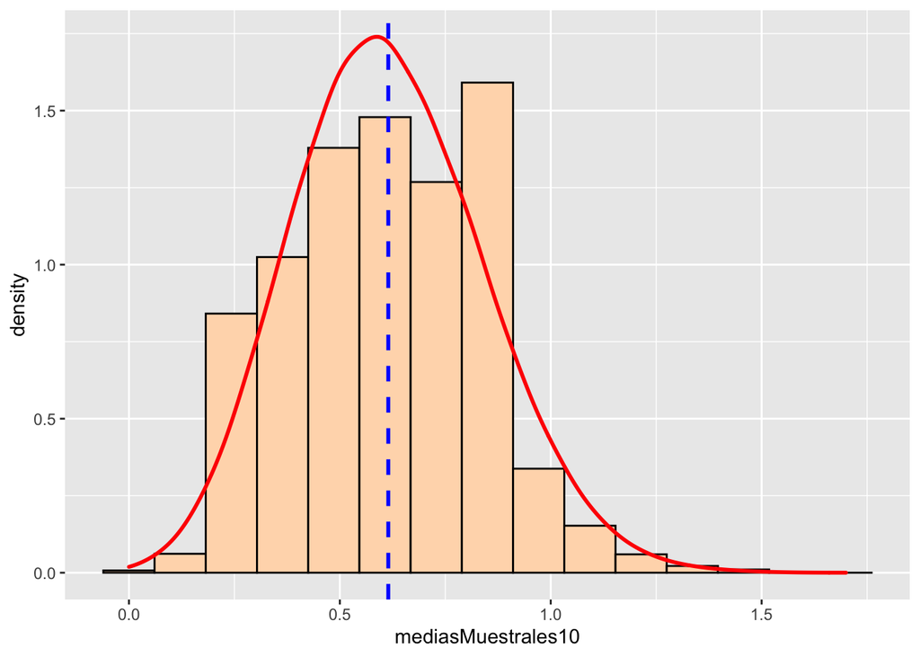

```r
library(ggplot2)
ggplot() +
geom_histogram(aes(x = mediasMuestrales10,y=stat(density)), bins = 15, fill="peachpuff", color="black") +
geom_vline(xintercept = mean(mediasMuestrales10),
col="blue", linetype="dashed",lty=1, lwd=1, size=1) +
  geom_density(mapping = aes(mediasMuestrales10),color="red",size=1,adjust=3)
```

Repetimos el ejercicio cambiando el tamaño de muestra por 30

```r
k=100000
mediasMuestrales30 <- replicate(k,{
  Z=sample(x1,size=30,replace=TRUE)
  mean(Z)
  })
head(mediasMuestrales30, 10)
```

```
##  [1] 0.7333333 0.7333333 0.6333333 0.4666667 0.7333333 0.7333333 0.8000000
##  [8] 0.6333333 0.5000000 0.5000000
```

Representación gráfica de la distribución de las medias muestrales

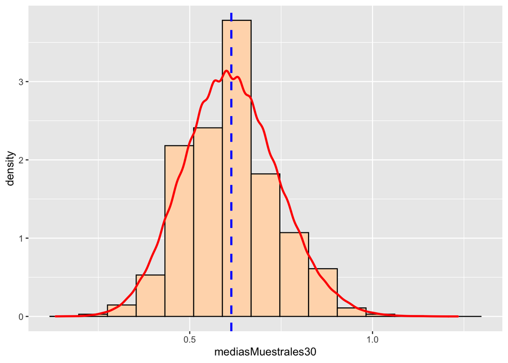

```r
ggplot() +
geom_histogram(aes(x = mediasMuestrales30,y=stat(density)), bins = 15, fill="peachpuff", color="black") +
geom_vline(xintercept = mean(mediasMuestrales30),
col="blue", linetype="dashed",lty=1, lwd=1, size=1) +
  geom_density(mapping = aes(mediasMuestrales30),color="red",size=1,adjust=1.5)
```

**Apartado 3:** La variable aleatoria discreta $X2$ tiene esta tabla de densidad de probabilidad:
$$\begin{array}{|c|c|c|c|c|c|}
\hline
\text{valor de }X2 & 0 & 1 & 2 \\
\hline
\text{Probabilidad de ese valor }P(X = x_i) & \dfrac{1}{2} &
\dfrac{1}{4}& \dfrac{1}{4}\rule{0mm}{6mm} \\[3mm]
\hline
\end{array}$$
Suponemos que $X1$ y $X2$ son independientes. ¿Qué valores puede tomar la suma $X1 + X2$? ¿Cuál es su tabla de probabilidad?

```r
set.seed(2021)
x2 <- sample(0:2,100,replace=TRUE, prob = c(1/2,1/4,1/4))
```

Vectores de probabilidades

```r
px1 <- c(64/125,48/125,12/125,1/125)
px2 <- c(1/2,1/4,1/4)
```

Probabilidad de que la suma de los dados de 0. Opciones: | x1 = 0 y x2 = 0 |

```r
(prob0 <- px1[1]*px2[1])
```

```
## [1] 0.256
```

Probabilidad de que la suma de los dados de 1. Opciones: | x1 = 1 y x2 = 0 | | x1 = 0 y x2 = 1 |

```r
(prob1 <- px1[1]*px2[2] + px1[2]*px2[1])
```

```
## [1] 0.32
```

Probabilidad de que la suma de los dados de 2. Opciones: | x1 = 0 y x2 = 2 | | x1 = 2 y x2 = 0 | | x1 = 1 y x2 = 1 |

```r
(prob2 <- px1[1]*px2[3] + px1[3]*px2[1] + px1[2]*px2[2])
```

```
## [1] 0.272
```

Probabilidad de que la suma de los dados de 3. Opciones: | x1 = 3 y x2 = 0 | | x1 = 1 y x2 = 2 | | x1 = 2 y x2 = 1 |

```r
(prob3 <- px1[4]*px2[1] + px1[2]*px2[3] + px1[3]*px2[2])
```

```
## [1] 0.124
```

Probabilidad de que la suma de los dados de 4. Opciones: | x1 = 3 y x2 = 1 | | x1 = 2 y x2 = 2 |

```r
(prob4 <-  px1[4]*px2[3] + px1[3]*px2[3] )
```

```
## [1] 0.026
```

Probabilidad de que la suma de los dados de 5. Opciones: | x1 = 3 y x2 = 2 |

```r
(prob5 <- px1[4]*px2[3])
```

```
## [1] 0.002
```

Tabla de probabilidades de la suma

```r
(tabla_prob <- matrix(c(prob0,prob1,prob2,prob3,prob4,prob5), nrow=1))
```

```
##       [,1] [,2]  [,3]  [,4]  [,5]  [,6]
## [1,] 0.256 0.32 0.272 0.124 0.026 0.002
```

```r
colnames(tabla_prob) <- c("prob0","prob1","prob2","prob3","prob4","prob5")
tabla_prob
```

```
##      prob0 prob1 prob2 prob3 prob4 prob5
## [1,] 0.256  0.32 0.272 0.124 0.026 0.002
```

**Apartado 4:** Calcula la media teórica de la suma $X_1 + X_2$. Después usa `sample` y `replicate` para simular cien mil *valores* de esta variable suma. Calcula la media de esos valores. *Advertencia:* no es el mismo tipo de análisis que hemos hecho en el segundo apartado.

```r
s=c(0,1,2,3,4,5)
(media_suma= sum(s*tabla_prob))
```

```
## [1] 1.35
```

```r
k=100000
medias = replicate(k,{
  Z=sample(s,prob=tabla_prob,size=1)
  })
mean(medias)
```

```
## [1] 1.3534
```

# Ejercicio 2. Datos limpios

- Descarga el fichero de este enlace

https://gist.githubusercontent.com/fernandosansegundo/471b4887737cfcec7e9cf28631f2e21e/raw/b3944599d02df494f5903740db5acac9da35bc6f/testResults.csv

```r
library(tidyverse)
resultados = read_csv("./data/testResults.csv")
```

- Este fichero contiene las notas de los alumnos de una clase, que hicieron dos tests cada semana durante cinco semanas. La tabla de datos no cumple los principios de *tidy data* que hemos visto en clase. Tu tarea en este ejercicio es explicar por qué no se cumplen y obtener una tabla de datos limpios con la misma información usando *tidyR*.  
  **Indicación:** lee la ayuda de la función `separate` de *tidyR*.

```r
library(tidyverse)
clean_resultados= pivot_longer(resultados,col=5:9,names_to='week')
clean_resultados = separate(clean_resultados,col=5,into=c("to_delete","week"),sep=4,convert=TRUE)
clean_resultados <- clean_resultados %>%
    select (-to_delete)
(clean_resultados = separate(clean_resultados,col=3,into=c("gender","age"),sep="_"))
```

```
## # A tibble: 1,000 × 7
##    name     id gender age   test_number  week value
##    <chr> <dbl> <chr>  <chr>       <dbl> <int> <dbl>
##  1 Jacob   108 m      20              1     1     8
##  2 Jacob   108 m      20              1     2     5
##  3 Jacob   108 m      20              1     3     7
##  4 Jacob   108 m      20              1     4     5
##  5 Jacob   108 m      20              1     5     6
##  6 Jacob   108 m      20              2     1     2
##  7 Jacob   108 m      20              2     2     2
##  8 Jacob   108 m      20              2     3     4
##  9 Jacob   108 m      20              2     4     0
## 10 Jacob   108 m      20              2     5     3
## # … with 990 more rows
```

# Ejercicio 3. Lectura de R4DS.

Contnuando con nuestra *lectura conjunta* de este libro, si revisas el índice verás que hemos cubierto (holgadamente en algún caso) el contenido de los Capítulos 6, 8, 9, 10 y 11. Todos esos Capítulos son relativamente ligeros. Por eso esta semana conviene detenerse un poco en la lectura de los Capítulos 7 y 12, que son los más densos en información. Y como motivación os proponemos un par de ejercicios, uno por cada uno de esos capítulos.

**Apartado 1:** Haz el [ejercicio 2 de la Sección 7.5.1.1 de R4DS](https://r4ds.had.co.nz/exploratory-data-analysis.html#exercises-17). Las ideas de esa sección son importantes para nuestro trabajo de las próximas sesiones.

2. What variable in the diamonds dataset is most important for predicting the price of a diamond? How is that variable correlated with cut? Why does the combination of those two relationships lead to lower quality diamonds being more expensive?

Con el siguiente gráfico se observa como afecta los quilates al precio del diamante. Se ha realizado una combinación de boxplots para poder así analizar los resultados de una manera más efectiva. El número de quilates si que afectan al precio del diamante.

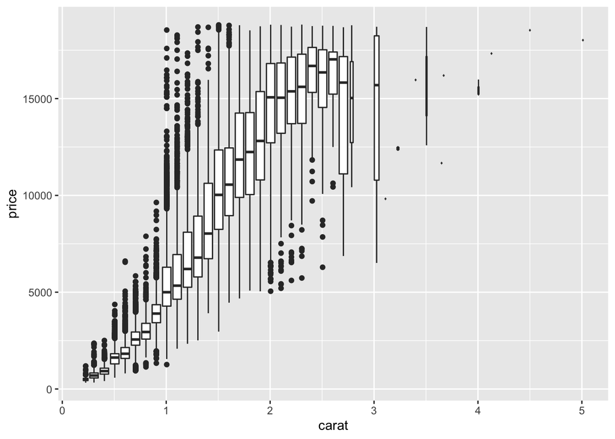

```r
ggplot(data = diamonds, mapping = aes(x = carat, y = price)) +
  geom_boxplot(mapping = aes(group = cut_width(carat, 0.1)), orientation = "x")
```

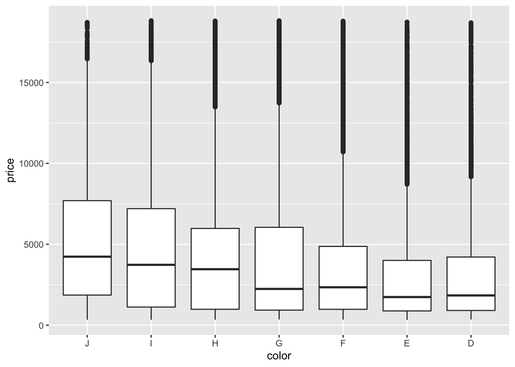

```r
diamonds %>%
  mutate(color = fct_rev(color)) %>%
  ggplot(aes(x = color, y = price)) +
  geom_boxplot()
```

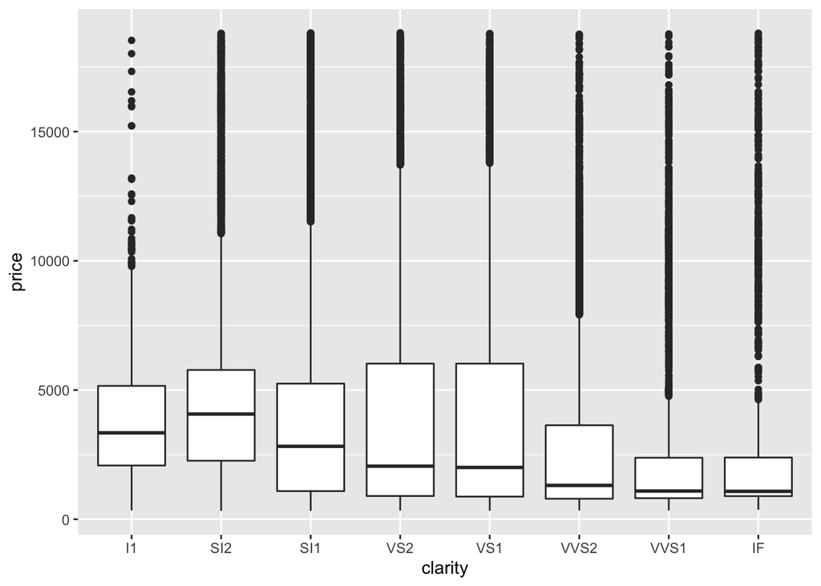

```r
ggplot(data = diamonds) +
  geom_boxplot(mapping = aes(x = clarity, y = price))
```

- Como conclusión, diré que el quilate es la variable que más afecta al precio de los diamantes con diferencia.

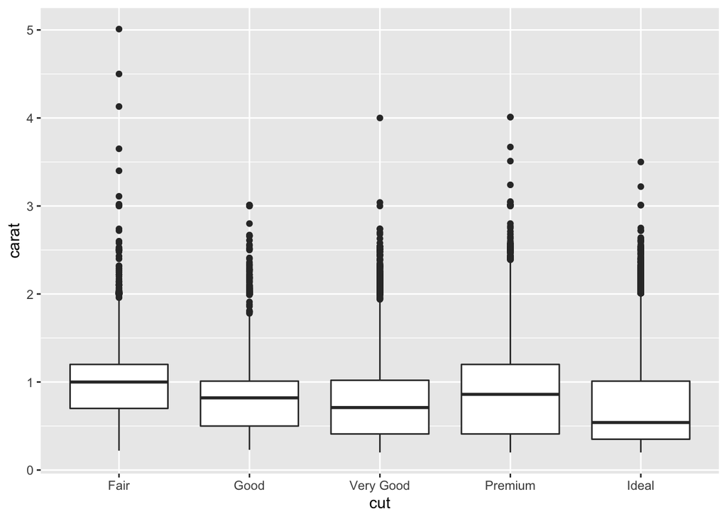

```r
ggplot(diamonds, aes(x = cut, y = carat)) +
  geom_boxplot()
```

- Como conclusión, diré que el quilate es la variable que más afecta al precio de los diamantes con diferencia. En cuanto a las otras variables, hay demasiada varablidiad El quilate es claramente el mejor indicador del precio de los diamantes. Hay mucha variabilidad en la distribución de los tamaños de quilates dentro de cada categoría de corte

**Apartado 2:** Haz el [ejercicio 4 de la Sección 12.6.1 de R4DS](https://r4ds.had.co.nz/tidy-data.html#exercises-27). ¡Aprovecha el código previo de esa sección para trabajar con datos limpios!

Codigo previo que limpia los datos de who.

```r
(who1 <- who %>%
  pivot_longer(
    cols = new_sp_m014:newrel_f65,
    names_to = "key",
    values_to = "cases",
    values_drop_na = TRUE
  ) %>%
  mutate(
    key = stringr::str_replace(key, "newrel", "new_rel")
  ) %>%
  separate(key, c("new", "var", "sexage")) %>%
  select(-new, -iso2, -iso3) %>%
  separate(sexage, c("sex", "age"), sep = 1))
```

```
## # A tibble: 76,046 × 6
##    country      year var   sex   age   cases
##    <chr>       <int> <chr> <chr> <chr> <int>
##  1 Afghanistan  1997 sp    m     014       0
##  2 Afghanistan  1997 sp    m     1524     10
##  3 Afghanistan  1997 sp    m     2534      6
##  4 Afghanistan  1997 sp    m     3544      3
##  5 Afghanistan  1997 sp    m     4554      5
##  6 Afghanistan  1997 sp    m     5564      2
##  7 Afghanistan  1997 sp    m     65        0
##  8 Afghanistan  1997 sp    f     014       5
##  9 Afghanistan  1997 sp    f     1524     38
## 10 Afghanistan  1997 sp    f     2534     36
## # … with 76,036 more rows
```

- For each country, year, and sex compute the total number of cases of TB. Make an informative visualization of the data.

Para saber que filtros realizar, realizamos una gráfca más general

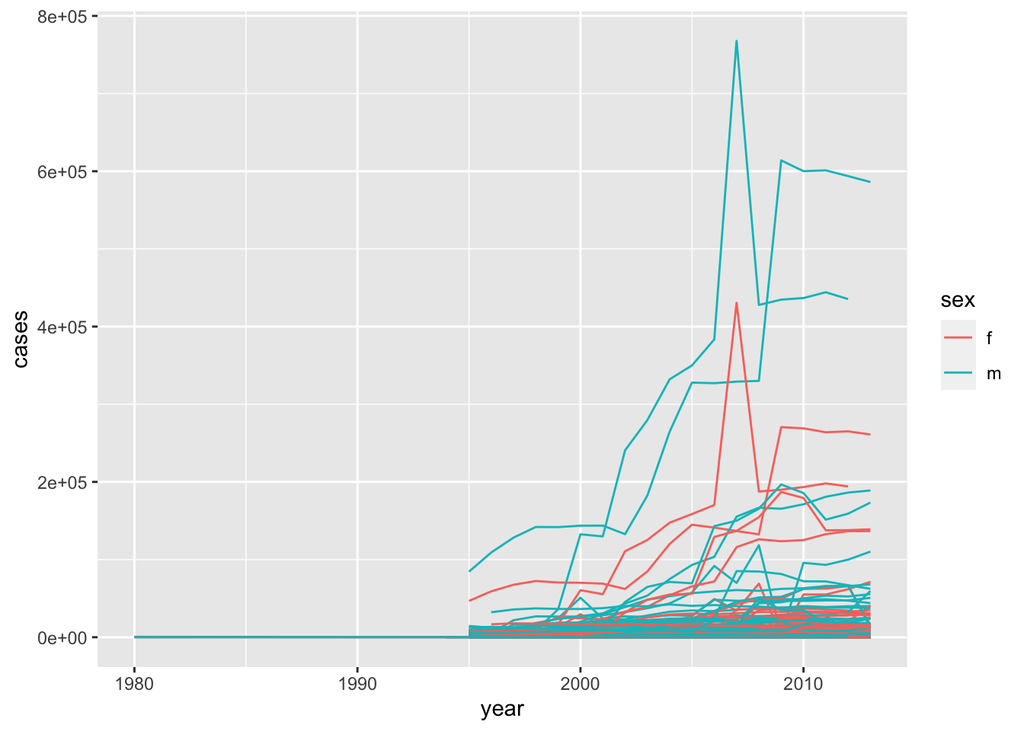

```r
who1 %>%
  group_by(country, year, sex) %>%
  summarise(cases = sum(cases)) %>%
  unite(country_sex, country, sex, remove = FALSE) %>%
  ggplot(aes(x = year, y = cases, group = country_sex, colour = sex)) +
  geom_line()
```

Observamos que los datos más significativos se encuentran despues del año 1995 y que hay un gran número de paises que no tienen datos de TB lo suficientemente relevantes para el estudio.

**Estudio**

A partir del año 1995, gráfica de los 10 paises donde hay más casos de TB teniendo cuenta, solamente, los hombres.

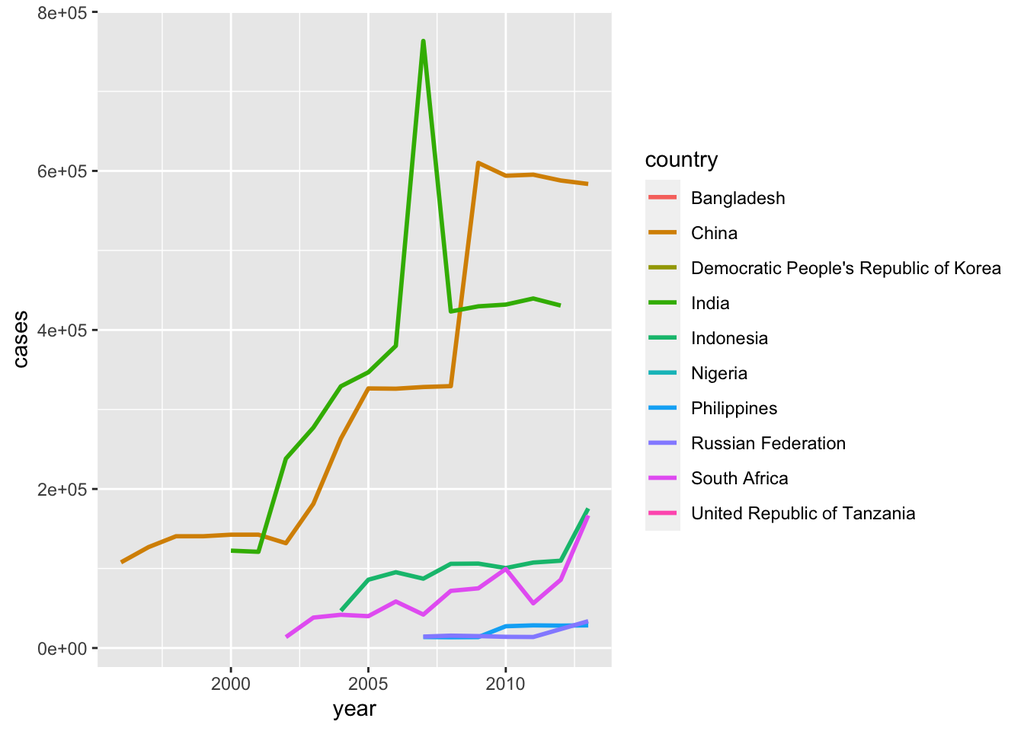

```r
who1 %>%
  group_by(country, year, sex) %>%
  filter(year > 1995) %>%
  filter(sex=="m") %>%
  filter(cases > 13500) %>%
  summarise(cases = sum(cases)) %>%
  unite(country_sex, country, sex, remove = FALSE) %>%
  ggplot(aes(x = year, y = cases, group = country_sex,color=country)) +
  geom_line(size=1)
```

A partir del año 1995, gráfica de los 10 paises donde hay más casos de TB teniendo cuenta, solamente, las mujeres.

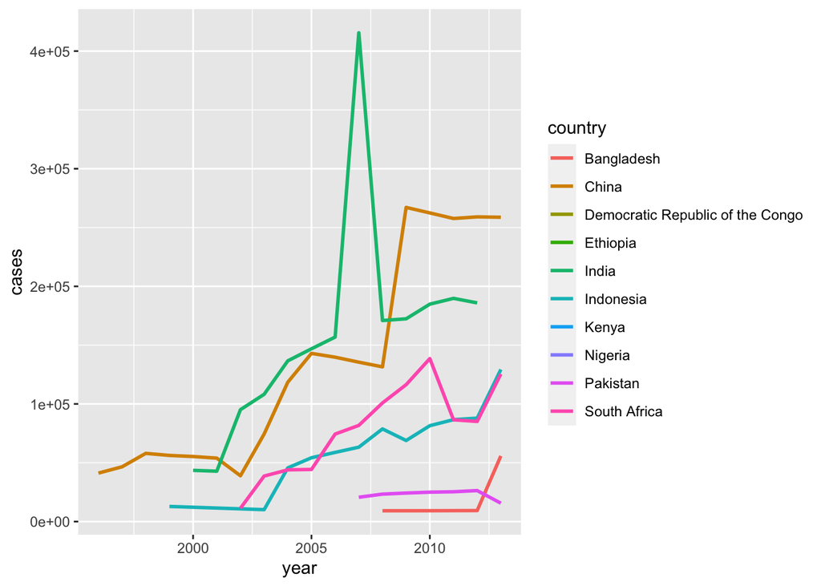

```r
who1 %>%
  group_by(country, year, sex) %>%
  filter(year > 1995) %>%
  filter(sex=="f") %>%
  filter(cases > 9000) %>%
  summarise(cases = sum(cases)) %>%
  unite(country_sex, country, sex, remove = FALSE) %>%
  ggplot(aes(x = year, y = cases, group = country_sex, color=country)) +
  geom_line(size=1)
```

Hombres vs mujeres. A partir del año 1995 graficando solamente los paises donde han habido más de 10000 casos.

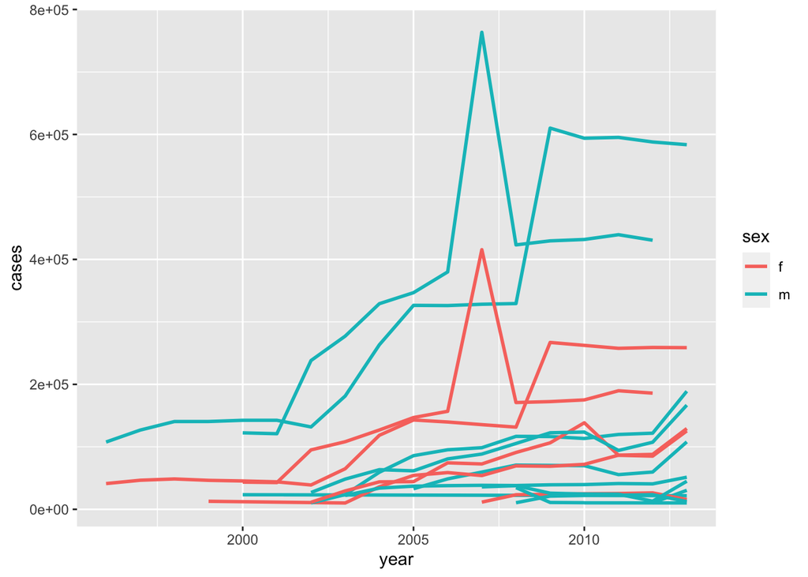

```r
who1 %>%
  group_by(country, year, sex) %>%
  filter(year > 1995) %>%
  filter(cases > 10000) %>%
  summarise(cases = sum(cases)) %>%
  unite(country_sex, country, sex, remove = FALSE) %>%
  ggplot(aes(x = year, y = cases, group = country_sex, colour = sex)) +
  geom_line(size=1)
```